# Coastwide analysis of forestry impacts on BC Pacific Salmon

March 2025

# 1 Models with forestry effects on productivity

## 1.1 Beverton-Holt (BH):

Model with static productivity, forestry:

$log(R_{t,r}/S_{t,r}) = \alpha_r - log(1+(\frac{e^{\alpha_r + \beta_{forestry,r}Forestry_{t,r} }}{R_{k,r}})S_{t,r}) + \beta_{forestry,r}Forestry_{t,r} + \rho \epsilon_{t-1,r}$

Model with time varying coast-wide productivity, forestry:

$log(R_{t,r}/S_{t,r}) = \alpha_t + \alpha_r - log(1+(\frac{e^{\alpha_t+\alpha_r + \beta_{forestry,r}Forestry_{t,r} }}{R_{k,r}})S_{t,r}) + \beta_{forestry,r}Forestry_{t,r} + \rho \epsilon_{t-1,r}$

Model with ocean covariates, forestry:

$log(R_{t,r}/S_{t,r}) = \alpha_r - log(1+(\frac{e^{\alpha_t+\alpha_r + \beta_{forestry,r}Forestry_{t,r}+ \beta_{npgo,r}NPGO_{t} + \beta_{sst,r}SST_{t,r} }}{R_{k,r}})S_{t,r}) + \beta_{forestry,r}Forestry_{t,r} + \beta_{npgo,r}NPGO_{t} + \beta_{sst,r}SST_{t,r} + \rho \epsilon_{t-1,r}$

Model with time varying coast-wide productivity, forestry, without autocorrelation:

$log(R_{t,r}/S_{t,r}) = \alpha_t + \alpha_r - log(1+(\frac{e^{\alpha_t+\alpha_r + \beta_{forestry,r}Forestry_{t,r} }}{R_{k,r}})S_{t,r}) + \beta_{forestry,r}Forestry_{t,r} + \epsilon_{t,r}$

## 1.2 Ricker:

Model with static productivity, forestry:

$log(R_{t,r}/S_{t,r}) = \alpha_r - \frac{S_{t,r}}{Smax_r} + \beta_{forestry,r}Forestry_{t,r} + \rho \epsilon_{t-1,r}$

Model with time varying coastwide productivity, forestry:

$log(R_{t,r}/S_{t,r}) = \alpha_t + \alpha_r - \frac{S_{t,r}}{Smax_r} + \beta_{forestry,r}Forestry_{t,r} + \rho\epsilon_{t-1,r}$

Model with ocean covariates, forestry:

$log(R_{t,r}/S_{t,r}) = \alpha_r - \frac{S_{t,r}}{Smax_r} + \beta_{forestry,r}Forestry_{t,r} + \beta_{npgo,r}NPGO_{t} + \beta_{sst,r}SST_{t,r} + \rho \epsilon_{t-1,r}$

Model with time varying coast-wide productivity, forestry, without autocorrelation:

$log(R_{t,r}/S_{t,r}) = \alpha_t + \alpha_r - \frac{S_{t,r}}{Smax_r} + \beta_{forestry,r}Forestry_{t,r} + \epsilon_{t,r}$

# 2 Models with forestry effects on carrying capacity

## 2.1 Beverton-Holt (BH):

Model with static productivity, forestry:

$log(R_{t,r}/S_{t,r}) = \alpha_r - log(1+\frac{(e^{\alpha_r} - 1)}{K_{t,r}} S_{t,r}) + \rho\epsilon_{t-1,r}$

Model with time varying coastwide productivity, forestry:

$log(R_{t,r}/S_{t,r}) = \alpha_r + \alpha_t - log(1+\frac{(e^{\alpha_r + \alpha_t} - 1)}{K_{t,r}} S_{t,r}) + \beta_{npgo,r}NPGO_{t} + \beta_{sst,r}SST_{t,r} + \rho\epsilon_{t-1,r}$

Model with ocean covariates, forestry:

$log(R_{t,r}/S_{t,r}) = \alpha_r - log(1+\frac{(e^{\alpha_r} - 1)}{K_{t,r}} S_{t,r}) + \beta_{npgo,r}NPGO_{t} + \beta_{sst,r}SST_{t,r} + \rho\epsilon_{t-1,r}$

Model with time varying coastwide productivity, forestry, without autocorrelation:

$log(R_{t,r}/S_{t,r}) = \alpha_r + \alpha_t - log(1+\frac{(e^{\alpha_r + \alpha_t} - 1)}{K_{t,r}} S_{t,r}) + \beta_{npgo,r}NPGO_{t} + \beta_{sst,r}SST_{t,r} + \epsilon_{t,r}$

## 2.2 Ricker:

Model with static productivity, forestry:

$log(R_{t,r}/S_{t,r}) = \alpha_r - \frac{\alpha_r}{K_{t,r}}S_{t,r} + \rho\epsilon_{t-1,r}$

Model with time varying coast-wide productivity, forestry:

$log(R_{t,r}/S_{t,r}) = \alpha_t + \alpha_r - \frac{\alpha_t + \alpha_r}{K_{t,r}}S_{t,r} + \rho \epsilon_{t-1,r}$

Model with ocean covariates, forestry:

$log(R_{t,r}/S_{t,r}) = \alpha_r - \frac{\alpha_r}{K_{t,r}}S_{t,r} + \beta_{npgo,r}NPGO_{t} + \beta_{sst,r}SST_{t,r} + \rho \epsilon_{t-1,r}$

Model with time varying coast-wide productivity, forestry, without autocorrelation:

$log(R_{t,r}/S_{t,r}) = \alpha_t + \alpha_r - \frac{\alpha_t + \alpha_r}{K_{t,r}}S_{t,r} + \epsilon_{t,r}$

### 2.2.1 Forestry effect on carrying capacity

$log(K_{t,r}) = log(K_r) + \beta_{forestry,r}Forestry_{t,r}$

$K_{t,r} = K_r e^{\beta_{forestry,r}Forestry_{t,r}}$

# 3 Chum and Pink Salmon Watersheds

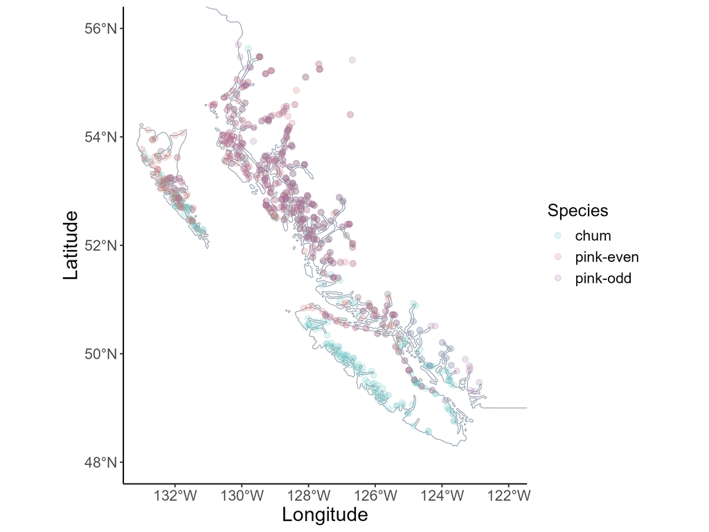

## 3.1 Extended Reconstructed Sea Surface Temperature (ERSST)

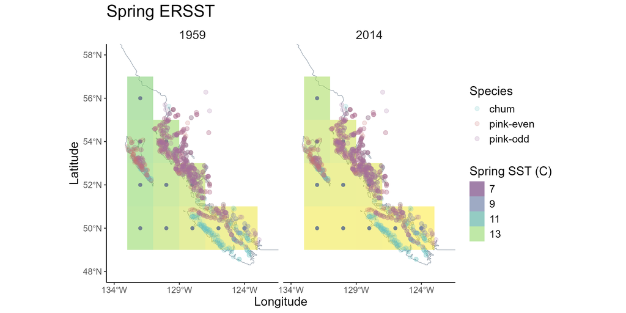